# Building models

Ben Whalley, Paul Sharpe, Sonja Heintz

[figure not shown]

# Overview

In this workshop we introduce *multiple regression*, that is: regression models which include 2 or more predictors. Multiple regression is a core technique in psychology and most other quantitative sciences.

In this workshop we focus on the case where you have one continuous outcome variable, and two continuous predictor variables. The notes emphasise the connection between *graphical models*, that represent hypotheses about how the data were generated, with specific linear models. To evaluate multiple regression models we can check their *residuals*, and to compare models we can use a Bayes Factor: both techniques are demonstrated.

### Learning outcomes

- Add multiple predictors to a linear model
- Calculate and interpret how much variation a model explains using $R^2$
- Calculate a Bayes Factor for a model to compare hypotheses

# Using multiple regression

[video not shown]

**Summary**

We often have multiple possible predictors of an outcome variable. We want to run models which use more than one predictor. We also need to compare different models to see which is the best.

This first video explains how to fit multiple regression models which include more than one predictor.

**Code**

```r
# load libraries
library(psydata)
library(tidyverse)


# check data we will use
fuel %>% glimpse()


# make some illustrative plots
fuel %>% ggplot(aes(weight, mpg)) + geom_point()
fuel %>% ggplot(aes(cyl, mpg)) + geom_point()
fuel %>% ggplot(aes(cyl, weight)) + geom_point()



# run and save linear models to match the possible hypotheses
modelA <- lm(mpg ~ weight, data=fuel)
modelB <- lm(mpg ~ weight + cyl, data=fuel)

# look at the coefficients from each model
modelA
modelB
```

**Explanation**

This video provides an overview of multiple regression, and does a rapid walk-through of fitting two models which represent *different hypotheses* about how the `fuel` dataset was generated.

In the rest of this workshop we break down the techniques used, and so the code is not explained in detail in this transcript; work through the explanations and examples below for full details.

However, some key ideas to take away are:

- Multiple regression includes more than one predictor of an outcome
- By comparing models with *different* predictors we are testing different hypotheses about the data

In the example, there are three variables in the `fuel` dataset that we use, recording attributes of various cars: `weight` (the car’s weight in kg), `cyl` (the number of cylinders the engine has), and `mpg` (how many miles per gallon the car can drive).

I run a model where `mpg` is predicted by weight, which I call `modelA`.

I then add `cyl` to the model formula, to say that `mpg` is predicted by `weight` and `cyl`. The formula is `mpg ~ weight + cyl`.

In the video we check the output of the model and see that there is an extra coefficient (more on this in the notes below).

We notice also that the coefficient for `weight` changes when we add `cyl`. This is also to be expected and is explained further below.

## Fuel Economy Example

The `fuel` dataset contains information about a selection of cars. *Our task*: We want to understand the relationship between fuel economy, the weight of a car, and how many cylinders it has.

We can plot the data to give us some clues. First, we see that as car weight goes up, fuel economy goes down:

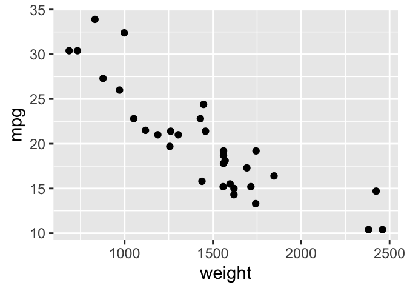

We also see that as the number of cylinders goes up, economy goes down:

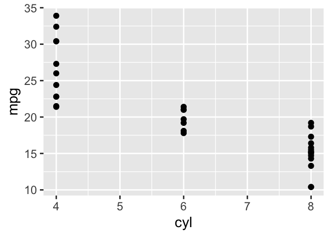

We might conclude that both weight and the number of cylinders are important. But we need to be careful! If we plot weight against the number of cylinders, we can see that these predictors are also related.

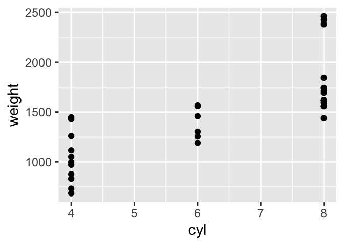

*Our problem*: We don’t know which of these predictors (weight or number of cylinders) are important. It’s possible that *confounding* is occurring and one of these relationships is *spurious*.

# Choosing between hypotheses

We want to distinguish between (at least) two hypotheses. We can represent them visually like this:

[output not shown]

# Adding a second predictor

We can think of linear models as representing different hypotheses. In the diagrams above:

- Hypothesis A is a model with a single predictor of fuel economy (`weight`)
- Hypothesis B is a model with two predictors of fuel economy (`weight` and number of cylinders, `cyl`)

Our task is to:

1. Fit both models
2. Quantify how well each one fits the data
3. Compare them, and choose the simplest model which fits the data well

In session 6 we saw how to define the outcome and predictor variables for a simple regression. For example:

```r
modelA <- lm(mpg ~ weight, data=fuel)
```

To add a second predictor to our `lm` model we just use the `+` symbol. For example:

```r
modelB <- lm(mpg ~ weight + cyl, data=fuel)
```

**Explanation of the code**: To add a second predictor to our model we used the `+` symbol to separate the names of the two predictors: `weight + cyl`. This makes R estimate coefficients for both predictor variables.

## Additional coefficients in the output

If we look at the output from `modelA` and `modelB` we can see that Model A’s output looks similar to those we ran before:

```r
modelA
```

```
Call:
lm(formula = mpg ~ weight, data = fuel)

Coefficients:
(Intercept)       weight
   37.28714     -0.01178
```

As before we have two coefficients:

- **`intercept`**, which represents the height of the regression line when the predictors equal zero
- **`weight`**, which represents the steepness of the slope (i.e. how strongly weight predicts economy)

However, the output for model B differs slightly:

```r
modelB
```

```
Call:
lm(formula = mpg ~ weight + cyl, data = fuel)

Coefficients:
(Intercept)       weight          cyl
  39.687037    -0.007037    -1.507643
```

We have the intercept, and the slope for `weight` as before. But there is an extra coefficient, for `cyl`.

This is the *change in the outcome* we expect *for each extra cylinder* the engine has, i.e. for each unit increase in the `cyl` variable.

### Making predictions with 2 predictors

If we want to make predictions, we now have to use both `weight` and `cyl`, but the process is very similar. Imagine we have a car with 4 cylinders, which weighs 1500kg (so `weight`=1500).

Our prediction is:

$intercept + (b_{cyl} \times 4) + (b_{weight} \times 1500)$

where $b_{cyl}$ and $b_{weight}$ are the coefficients for `cyl` and `weight`.

So, in this case, our prediction would be:

- The intercept is 39
- The slope for `weight` is -.007
- The slope for `cyl` is -1.5

So the calculation is $39 + 1500 \times -.007 + 4 \times -1.5 = 22.5$ (allowing for rounding errors).

We could also use `augment` to make the prediction, as we did in the previous session:

```r
# the .fitted column is the prediction
augment(modelB, newdata=tibble(weight=1500, cyl=4))
```

```
# A tibble: 1 × 3
  weight   cyl .fitted
   <dbl> <dbl>   <dbl>
1   1500     4    23.1
```

`augment` predicts 23.1, but this is because it did not round the coefficients before doing the multiplication. The result is approximately the same (and close enough).

## Understanding changes in the coefficients

Coefficients can change when adding new predictors.

You might notice that the `weight` coefficient has changed between the two models. In `modelA` it is -0.012, but in model B it is -0.007

Why did it shrink towards zero?

The coefficients are the change in the outcome for a 1 unit change in the predictor *IF* all the other predictors had stayed at the same value.

We describe this as the effect of additional weight, *adjusting for* how many cylinders the car had.

So, in this example, *once we have adjusted for the number of cylinders*, the *adjusted* (or *partial*) effect of weight is reduced (although not eliminated).

It can help to imagine what would happen if we fit a regression:

1. For the whole sample, ignoring the number of cylinders (like in model A)
2. Separately for cars with 4, 6 and 8 cylinders.

The plot below shows what this would look like:

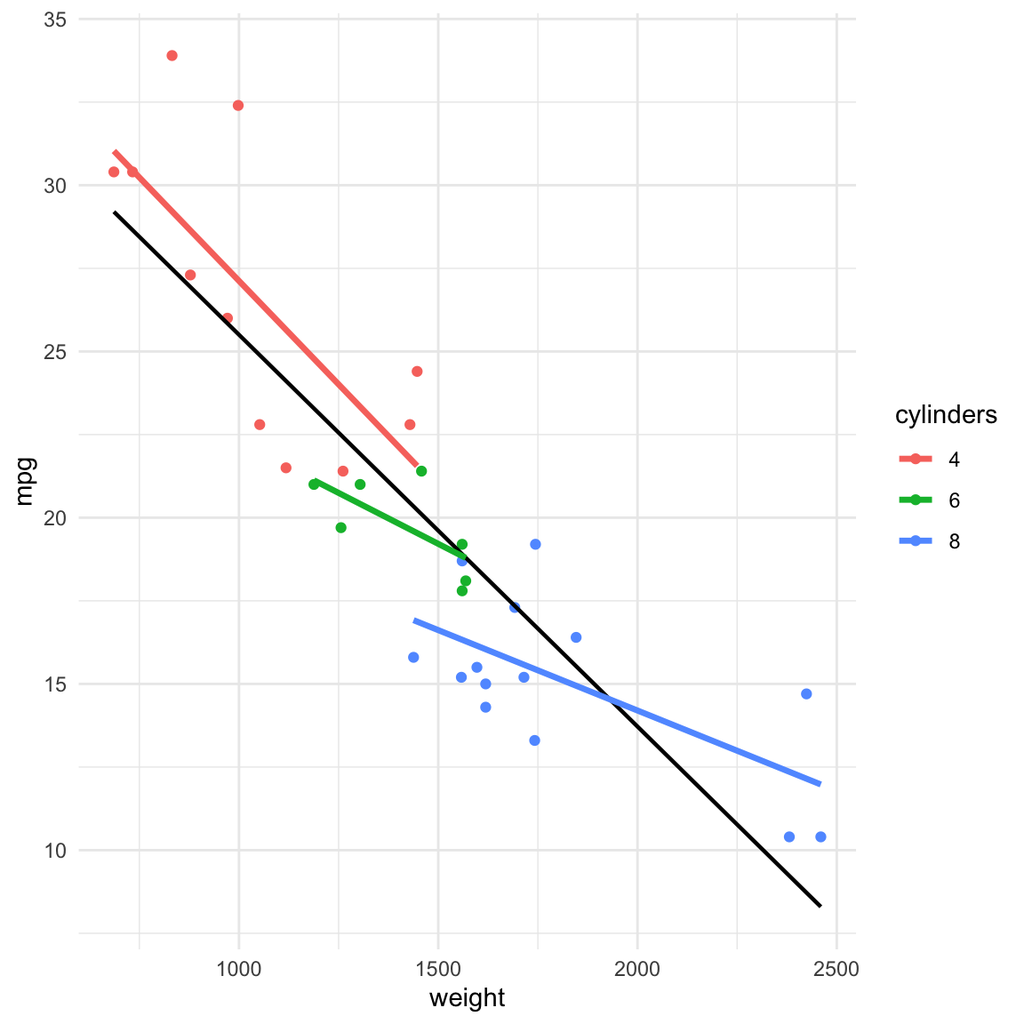

The coefficient `weight` in model A is equivalent to the black line. The coefficient `weight` in model B, is approximately equivalent to the average of the red, green and blue slopes.

We can see that the *average* slope of the red, green and blue lines is less steep than the black line. That is, *once we have accounted for the number of cylinders, our estimate of the relationship between weight and economy is reduced.*

# *Evaluating* models

[video not shown]

**Summary**

How do we know which of the two models is the best?

One way is to check the residuals from each model (and plot them). Smaller residuals are better.

The $R^2$ statistic formalises this somewhat. It is a number from 1 (the model predicts the outcome perfectly) to 0 (the model doesn’t predict anything).

Always report the ‘adjusted $R^2$’.

**Code**

```r
# calculate R squared
glance(modelA)
glance(modelB)
```

**Explanation**

We saw previously that residuals represent the *distance between the predicted and observed data*. *Larger residuals mean bigger errors in prediction*, and smaller errors are better.

The plot below shows the *distribution* of residuals from models A and B.

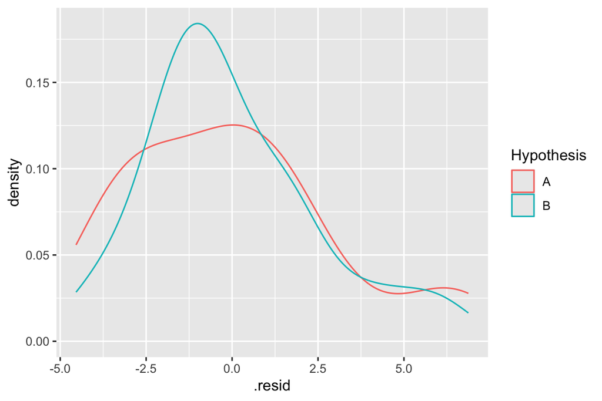

Based on the distribution of the residuals, which model seems to make the best predictions?

Model B (representing Hypothesis B) makes better predictions, because more of the residuals are clustered around zero. That is, the error in the predictions is smaller.

## R-squared (*R*<sup>2</sup>)

$R^2$ is the proportion of variance in the outcome explained by the predictor variables.

$R^2$ summarises how large the residuals are for different models, relative to the residual from a model without any predictors.

It ranges from 0 (models which are very poor and have large residuals), to 1 (models with perfect prediction and zero residuals). Because larger $R^2$ values are better, we can use it to compare models with additional predictors.

To calculate $R^2$ we use the `glance` function on our saved model result:

```r
glance(modelA)
```

```
# A tibble: 1 × 12
  r.squared adj.r.squared sigma statistic  p.value    df logLik   AIC   BIC
      <dbl>         <dbl> <dbl>     <dbl>    <dbl> <dbl>  <dbl> <dbl> <dbl>
1     0.753         0.745  3.05      91.4 1.29e-10     1  -80.0  166.  170.
# ℹ 3 more variables: deviance <dbl>, df.residual <int>, nobs <int>
```

*Explanation of the code*: We use the `glance` function, providing our saved result for `modelA` as the input.

*Explanation of the output*: `glance` produces a data frame as a result, containing columns for `r.squared`, `adj.r.squared`, and some other statistics which we don’t need for now. The number to focus on here is `adj.r.squared`, which is 0.75.

Why use the *adjusted* $R^2$, and what is the adjustment?

Unadjusted, $R^2$ becomes increasingly over-optimistic as we add extra predictors to our model. The adjusted $R^2$ figure corrects for this, reducing the raw $R^2$ as we add extra predictors.

*Always report the adjusted* $R^2$ value.

For more detail, see Field’s (2012) textbook, *Discovering Statistics Using R*, p. 273.

We can repeat the process for `modelB`:

```r
glance(modelB)
```

```
# A tibble: 1 × 12
  r.squared adj.r.squared sigma statistic  p.value    df logLik   AIC   BIC
      <dbl>         <dbl> <dbl>     <dbl>    <dbl> <dbl>  <dbl> <dbl> <dbl>
1     0.830         0.819  2.57      70.9 6.81e-12     2  -74.0  156.  162.
# ℹ 3 more variables: deviance <dbl>, df.residual <int>, nobs <int>
```

*Explanation of the output*: This time we calculated `adj.r.squared` for `modelB`, which included `cyl` as an extra predictor. Adjusted $R^2$ has now gone up to 0.82.

To summarise the results above:

- We predicted fuel economy using `weight` alone (model A) and adjusted $R^2$ was 0.75.
- We added `cyl` (number of cylinders) in model B. Adjusted $R^2$ increased to 0.82.

Models with higher $R^2$ have smaller residuals and make better predictions. This means we should generally prefer model B.

But, if the increase in $R^2$ is only small we might worry that the difference is due to chance — for example, because of random variations in our dataset. The final step is to quantify the evidence for each hypothesis.

# Strength of the evidence

[video not shown]

**Summary**

Our final task is to *quantify how much evidence* we have that model B is better than model A. For this we use a Bayes Factor.

**Code**

```r
library(BayesFactor)

mA <- lmBF(mpg ~ weight, data=fuel)
mB <- lmBF(mpg ~ weight + cyl, data=fuel)


mB / mA
```

**Explanation**

As we saw in session 5, a Bayes Factor always compares two hypotheses. It tells us how many times more likely the data we collected are under one hypothesis than under an alternative hypothesis.

We will use Bayes Factors to compare hypotheses A and B, which are represented by model A and model B.

To calculate the Bayes Factor we need to:

- Load the `BayesFactor` package
- Re-run our models using the `lmBF` function
- Divide model B by model A

The complete code is as follows:

```r
# load the package first
library(BayesFactor)
```

Next we re-run the models using the `lmBF` function. The only change is to replace `lm` with `lmBF`.

```r
# save model A
mA <- lmBF(mpg ~ weight, data=fuel)

# save model B
mB <- lmBF(mpg ~ weight + cyl, data=fuel)
```

Finally, we divide model B by model A to calculate the Bayes Factor.

```r
# evidence in favour of model B
mB / mA
```

```
Bayes factor analysis
--------------
[1] weight + cyl : 22.7057 ±0.01%

Against denominator:
  mpg ~ weight
---
Bayes factor type: BFlinearModel, JZS
```

*Explanation of the code*: We divide `mB` by `mA` using the `/` symbol.

*Explanation of the output*: Our code produces a Bayes Factor showing the evidence *in favour of model B*. The Bayes Factor is 22.71.

### Interpreting the Bayes Factor

In session 5 we learned that a BF > 10 is generally considered **strong** evidence in favour of a hypothesis.

In this example the Bayes Factor is 22.71, so we have strong evidence in favour of model B, compared with model A.

Put differently, the data we collected are 22 times more likely under model B than under model A.

# Interpreting Bayes Factors

We previously said that:

- BFs > 3 are *moderate* evidence *for* a hypothesis, and
- BF < 0.33 ($\tfrac{1}{3}$) are moderate evidence *against* a hypothesis.

Psychologists love a “line in the sand”, so a convention has emerged that we believe an effect is ‘real’ if the Bayes Factor is greater than 3, and believe there isn’t a ‘real’ effect if the Bayes Factor is less than 0.33.

In fact though, Bayes Factors are a *continuous measure of the evidence* for or against a particular model (hypothesis).

Several authors have written guidelines on how to interpret Bayes Factors in this way. They provide labels for Bayes Factors of various sizes. This is more useful than a simple “line in the sand”, especially when comparing multiple studies. The labels below are from Lee & Wagenmakers (2013), who adapted them from Jeffreys (1961). Kass & Raftery (1995) proposed a similar scheme with slightly different cut-offs.

A rule-of-thumb interpretation of Bayes Factors

| Bayes Factor | Interpretation |
| --- | --- |
| > 100 | Extreme evidence for the hypothesis tested |
| 30 - 100 | Very strong evidence for the hypothesis tested |
| 10 - 30 | Strong evidence for the hypothesis tested |
| 3 - 10 | Moderate evidence for the hypothesis tested |
| 1 - 3 | Anecdotal evidence for the hypothesis tested |

‘Anecdotal’ evidence (a BF between 1 and 3) is what we called *inconclusive* in session 5.

**Bayes Factors can also be smaller than 1. These indicate support for the *other* hypothesis**: the one on the bottom of the division (when we test an effect against ‘no effect’, this is the null hypothesis). The same labels apply in reverse: for example, a BF of 0.05 is strong evidence for the other hypothesis (because $1/0.05 = 20$), but a BF between $\tfrac{1}{3}$ and 1 is still inconclusive. If a BF is less than 1 we often find it helpful to reverse the order of division so that the BF is larger than 1, and state explicitly in the text which hypothesis the BF supports.

Imagine we are comparing two regression models, A and B. In the R output we see that the Bayes Factor for model A is 22, and the Bayes Factor for Model B is 560.

- Which model do the data support?
- The BF in favour of model B is:
- The BF in favour of model A is (to 2 decimal places):
- For the BF in favour of model A, we calculate $BF_{A} / BF_{B}$ = 22/560 = 0.04
- For the BF in favour of model B, we calculate $BF_{B} / BF_{A}$ = 560/22 = 25.5

Note that $1 / 0.039 = 25.5$. We can use this trick ([taking the reciprocal](https://www.cliffsnotes.com/cliffsnotes/subjects/math/in-math-what-does--i-reciprocal-i-mean)) to ‘reverse’ any Bayes Factor that is < 1 so that it expresses evidence in favour of the other hypothesis.

# Overall synopsis

In the example above our outcome variable was fuel economy and we had two potential predictor variables: the car’s weight, and the number of cylinders it had.

We ran two models (A and B) which represented *different hypotheses*:

- Hypothesis A said *only weight* was needed to predict fuel economy.
- Hypothesis B said that *both weight and cylinders* would be *independent predictors* of fuel economy.

After fitting both models using `lm` we calculated $R^2$ to estimate how well each model fitted the data.

$R^2_{adjusted}$ was .75 for model A, and .82 for model B, which means both models were quite good. Both explained a large proportion of the variability in fuel economy.

To *compare the models*, we re-fitted them using `lmBF` and calculated a Bayes Factor. This told us that — although both were quite a good fit to the data — the data were 22 times more likely under model B than under model A.

From this example we conclude that *both weight and cylinders are independent predictors of fuel economy*. That is, both variables make a useful contribution when predicting fuel economy.

# Check your knowledge

Write an answer to each of these questions in the `Check your knowledge` section of your workbook.

1. We prefer models with residuals
2. The $R^2$ statistic ranges from:
3. It’s better for a model to have a $R^2$ value
4. If we calculate the Bayes Factor for `modelA / modelB` and the result is > 1, this provides evidence that
5. A Bayes Factor of 25 means we have evidence
6. A Bayes Factor of 0.05 means we have

# Additional examples and exercises

To consolidate what we have learned this section asks you to follow the same process using a different dataset.

## Student study habits

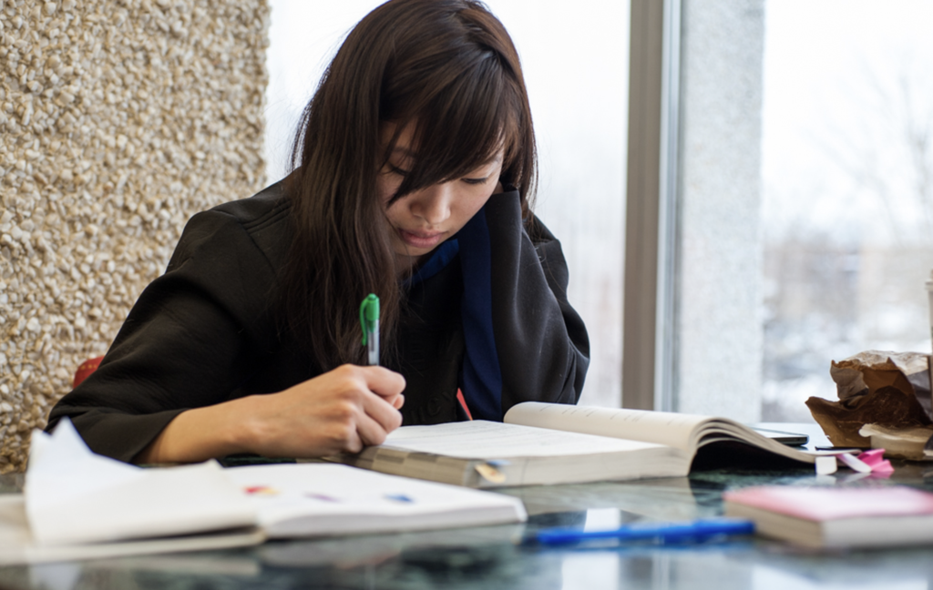

The `studyhabits` dataset (in the `psydata` package) contains data on students and their study habits:

- `work_hours`: How many hours per week the student worked
- `work_consistently`: A measure of how consistently the student worked each day
- `grade`: Their assessment grade (%)

The tasks below use these data to pose a series of questions to check your understanding. They ask you to run additional analyses to build confidence using R.

#### Task 1: Interpret these plots

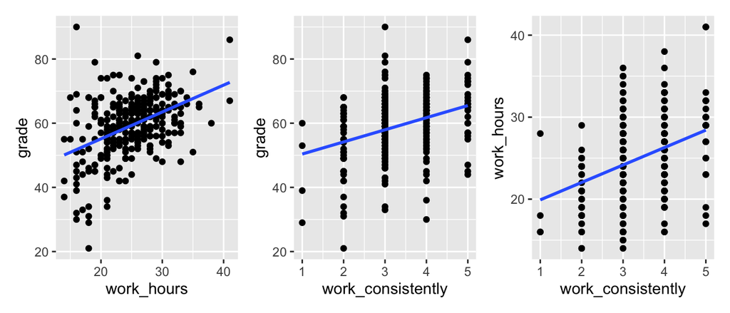

Based on these plots of the `studyhabits` data:

- Hours worked and assessment grades are
- Working consistently is likely to produce grades
- Students who work more consistently tend to work for time overall

#### Task 2: Describe alternative hypotheses

Imagine we are interested in *the effect of working consistently each day on grades, adjusting for the total number of hours studied*. That is, we want to know if working consistently helps predict grades, even after we know the total hours spent studying.

A. Fill in the blanks in the following diagram:

[interactive chart not shown]

B. Which hypothesis do you think is more likely, based on the plots and your own experience?

#### Task 3: Write the model code

What is the correct code to run models for each of the hypotheses we described above?

- Hypothesis A:
- Hypothesis B:

#### Task 4: Calculate the Bayes Factor

Imagine you have already run the following code:

```r
modA <- lmBF(grade ~ work_hours, data=studyhabits)
modB <- lmBF(grade ~ work_hours + work_consistently, data=studyhabits)
```

- The code to calculate the Bayes Factor in favour of Model B is:

```r
modB / modA
```

```
Bayes factor analysis
--------------
[1] work_hours + work_consistently : 91.26606 ±0.01%

Against denominator:
  grade ~ work_hours
---
Bayes factor type: BFlinearModel, JZS
```

#### Task 5: Interpret the Bayes Factor output

Imagine you had run the code below:

```r
modA <- lmBF(grade ~ work_hours, data=studyhabits)
modB <- lmBF(grade ~ work_hours + work_consistently, data=studyhabits)
```

Interpret the following output:

```r
modB
```

```
Bayes factor analysis
--------------
[1] work_hours + work_consistently : 6.627368e+13 ±0%

Against denominator:
  Intercept only
---
Bayes factor type: BFlinearModel, JZS
```

- We can interpret the Bayes Factor in this output as saying:
- The Bayes Factor for model B is:

In the section above we only look at the output of `modB`. The default in the `BayesFactor` package is to give the BF for the comparison against a model with no predictors. This is *sometimes* what you want, but normally you will have to divide one model by another to get the correct Bayes Factor.

The BF number is written in scientific notation as `6.627368e+13` This means it is roughly $6.627 \times 10^{13}$, so about 66273680000000.

Always double check when you see an `e` in a number in R output.

Useful: https://www.calculatorsoup.com/calculators/math/scientific-notation-converter.php

#### Task 6: Interpret the Bayes Factor comparing two models

Now interpret the following output:

```r
modB / modA
```

```
Bayes factor analysis
--------------
[1] work_hours + work_consistently : 91.26606 ±0.01%

Against denominator:
  grade ~ work_hours
---
Bayes factor type: BFlinearModel, JZS
```

- Which of the following options is true:

## National happiness

[figure not shown]

This last exercise is not *required*; it is offered as an additional challenge for students who have time, or who wish to practice and consolidate skills learned.

The plots below show the distribution of and relationship between three columns in the `happy` dataset, in the `psydata` package.

These data are a simplified version of the [Gallup World Happiness Report](https://worldhappiness.report/ed/2021) (see the report for more details on the questions asked).

The columns shown are the national average of responses to three questions:

- `happiness`: a measure of subjective well-being, rated on the Cantril ladder from 0 (worst possible life) to 10 (best possible life)
- `social_support`: responses to the question: “If you were in trouble, do you have relatives or friends you can count on to help you whenever you need them, or not?”
- `freedom_to_make_life_choices`: responses to “Are you satisfied or dissatisfied with your freedom to choose what you do with your life?”

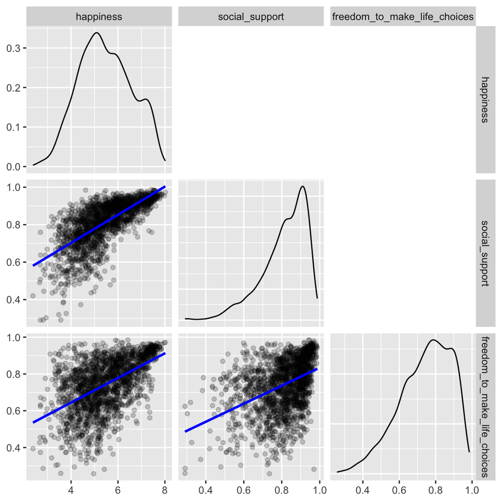

#### Task 7: National happiness

Using the `happy` data:

- Write code to run linear models to predict `happiness` using the `social_support` and `freedom_to_make_life_choices` columns.
- Draw diagrams to describe two alternative hypotheses, similar to those used above.
- Calculate a Bayes Factor which compares those two alternative hypotheses. Which hypothesis is more likely?

There is no single set of ‘correct’ answers to these questions. If you would like feedback on your work, speak to a member of staff during the workshops.

### References

Kass, R. E., & Raftery, A. E. (1995). Bayes factors. *Journal of the American Statistical Association*, *90*(430), 773–795.

Lee, M. D., & Wagenmakers, E.-J. (2013). *Bayesian cognitive modeling: A practical course*. Cambridge University Press.